# W6_class_notes

# Analysis

Chocolate.html Chocolate.Rmd

# Announcements

In 3 weeks (DO IT NOW) - data set - quesitn about the data set

best: find a small business that would like some help. (KAI’S SHOE STORE? GAME PULSE? IMDB? SLEEP DATA? )

# Kruskal-Wallis Test

## Why

An ANOVA test requires the dataset with more than 2 factors to have a normal distribution. Kruskal-Wallis Tests can test more than 2 factors without needing a normal distribution.

Can also be used when data is ordered (ordinal) but does not have an exact measurement.

## How

You really just do three things: - run a kruskal - make a boxplot - show the datatable

### Example pigweights

```r
pigweights <- data.frame(Subject=1:56,
                   Litter=factor(rep(1:8, c(10,8,10,8,6,4,6,4))),
                   Weight=c(2.0,2.8,3.3,3.2,4.4,3.6,1.9,3.3,2.8,1.1,
                            3.5,2.8,3.2,3.5,2.3,2.4,2.0,1.6,
                            3.3,3.6,2.6,3.1,3.2,3.3,2.9,3.4,3.2,3.2,
                            3.2,3.3,3.2,2.9,3.3,2.5,2.6,2.8,
                            2.6,2.6,2.9,2.0,2.0,2.1,
                            3.1,2.9,3.1,2.5,
                            2.6,2.2,2.2,2.5,1.2,1.2,
                            2.5,2.4,3.0,1.4))
knitr::kable(pigweights, align='l')
```

| Subject | Litter | Weight |
| --- | --- | --- |
| 1 | 1 | 2.0 |
| 2 | 1 | 2.8 |
| 3 | 1 | 3.3 |
| 4 | 1 | 3.2 |
| 5 | 1 | 4.4 |
| 6 | 1 | 3.6 |
| 7 | 1 | 1.9 |
| 8 | 1 | 3.3 |
| 9 | 1 | 2.8 |
| 10 | 1 | 1.1 |
| 11 | 2 | 3.5 |
| 12 | 2 | 2.8 |
| 13 | 2 | 3.2 |
| 14 | 2 | 3.5 |
| 15 | 2 | 2.3 |
| 16 | 2 | 2.4 |
| 17 | 2 | 2.0 |
| 18 | 2 | 1.6 |
| 19 | 3 | 3.3 |
| 20 | 3 | 3.6 |
| 21 | 3 | 2.6 |
| 22 | 3 | 3.1 |
| 23 | 3 | 3.2 |
| 24 | 3 | 3.3 |
| 25 | 3 | 2.9 |
| 26 | 3 | 3.4 |
| 27 | 3 | 3.2 |
| 28 | 3 | 3.2 |
| 29 | 4 | 3.2 |
| 30 | 4 | 3.3 |
| 31 | 4 | 3.2 |
| 32 | 4 | 2.9 |
| 33 | 4 | 3.3 |
| 34 | 4 | 2.5 |
| 35 | 4 | 2.6 |
| 36 | 4 | 2.8 |
| 37 | 5 | 2.6 |
| 38 | 5 | 2.6 |
| 39 | 5 | 2.9 |
| 40 | 5 | 2.0 |
| 41 | 5 | 2.0 |
| 42 | 5 | 2.1 |
| 43 | 6 | 3.1 |
| 44 | 6 | 2.9 |
| 45 | 6 | 3.1 |
| 46 | 6 | 2.5 |
| 47 | 7 | 2.6 |
| 48 | 7 | 2.2 |
| 49 | 7 | 2.2 |
| 50 | 7 | 2.5 |
| 51 | 7 | 1.2 |
| 52 | 7 | 1.2 |
| 53 | 8 | 2.5 |
| 54 | 8 | 2.4 |
| 55 | 8 | 3.0 |
| 56 | 8 | 1.4 |

```r
kruskal.test(Weight ~ Litter, data=pigweights)
```

```
##
##  Kruskal-Wallis rank sum test
##
## data:  Weight by Litter
## Kruskal-Wallis chi-squared = 18.565, df = 7, p-value = 0.009663
```

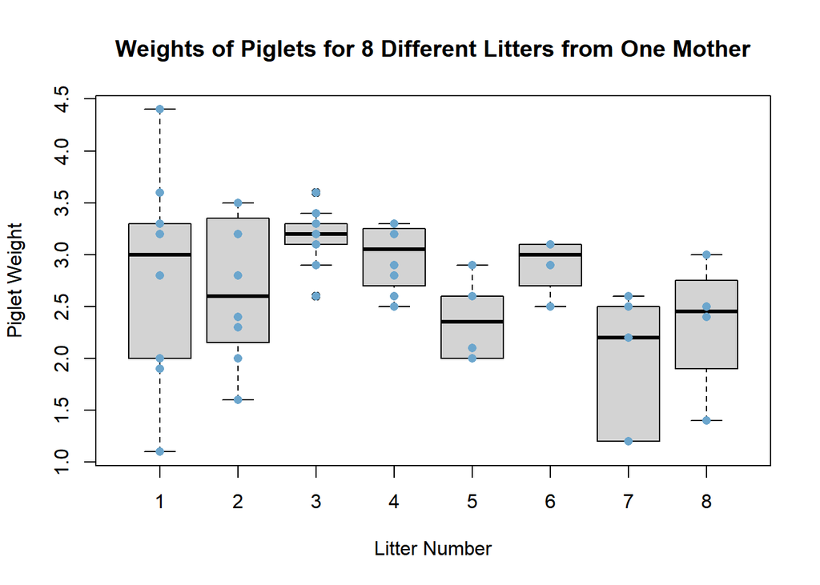

```r
boxplot(Weight ~ Litter, data=pigweights,
        col="lightgray", xlab="Litter Number", main="Weights of Piglets for 8 Different Litters from One Mother", ylab="Piglet Weight")
stripchart(Weight ~ Litter, data=pigweights,
           vertical=TRUE, pch=16, add=TRUE, col="skyblue3")
```

```r
pander(favstats(Weight ~ Litter, data=pigweights)[,-10])
```

| Litter | min | Q1 | median | Q3 | max | mean | sd | n |
| --- | --- | --- | --- | --- | --- | --- | --- | --- |
| 1 | 1.1 | 2.2 | 3 | 3.3 | 4.4 | 2.84 | 0.9536 | 10 |
| 2 | 1.6 | 2.225 | 2.6 | 3.275 | 3.5 | 2.663 | 0.705 | 8 |
| 3 | 2.6 | 3.125 | 3.2 | 3.3 | 3.6 | 3.18 | 0.2741 | 10 |
| 4 | 2.5 | 2.75 | 3.05 | 3.225 | 3.3 | 2.975 | 0.3196 | 8 |
| 5 | 2 | 2.025 | 2.35 | 2.6 | 2.9 | 2.367 | 0.383 | 6 |
| 6 | 2.5 | 2.8 | 3 | 3.1 | 3.1 | 2.9 | 0.2828 | 4 |
| 7 | 1.2 | 1.45 | 2.2 | 2.425 | 2.6 | 1.983 | 0.6274 | 6 |
| 8 | 1.4 | 2.15 | 2.45 | 2.625 | 3 | 2.325 | 0.6702 | 4 |

### Example Friendly

```r
kruskal.test(
  correct ~ condition,
  data = Friendly
  )
```

```
##
##  Kruskal-Wallis rank sum test
##
## data:  correct by condition
## Kruskal-Wallis chi-squared = 5.1817, df = 2, p-value = 0.07496
```

We have insufficient evidence to reject the null.

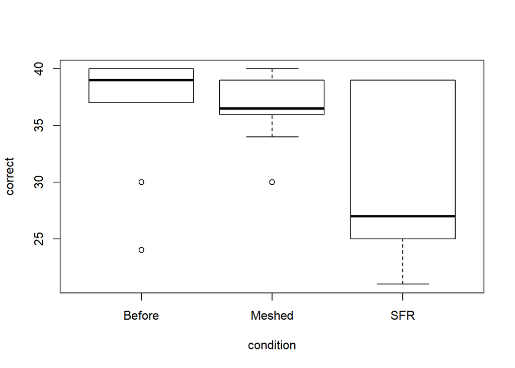

```r
boxplot(correct ~ condition,
  data = Friendly)
```

# Skills Quiz

## Question 1

Say a homeowner in Saratoga County, New York is curious about whether upgrading their home from an oil heating fuel system to either a gas or electric fuel system would increase the resale value of their home. Use the SaratogaHouses dataset in R and a Kruskal-Wallis Test to answer the question, “which heating system results in the hightest distribution of home resale values (price)?”

$H_0$: The null hypothesis for this study is that the prices of homes with either gas, oil, or electric heating fuel systems all come from the same distribution.

$H_a$: The alternative hypothesis is that at least one type of fuel system results in a different distribution of prices of homes.

### Kruskal-Wallis Test

Find test statistic, degrees of freedom, p-value, and highest median price of house for an individual fuel system.

```r
kruskal.test(
  price ~ fuel,
  data = SaratogaHouses
  )
```

```
##
##  Kruskal-Wallis rank sum test
##
## data:  price by fuel
## Kruskal-Wallis chi-squared = 159.66, df = 2, p-value < 2.2e-16
```

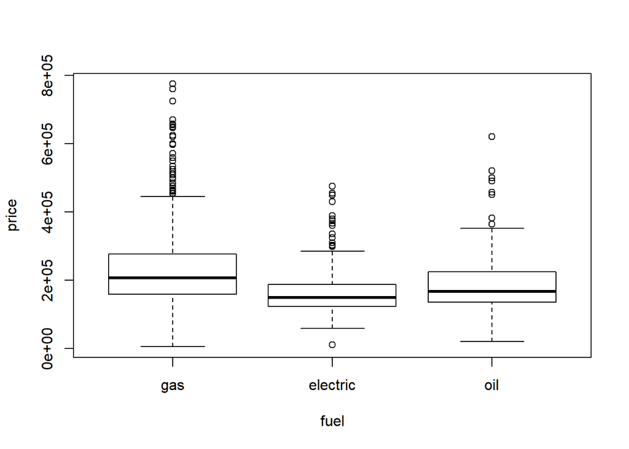

```r
boxplot(price ~ fuel, data=SaratogaHouses)
```

```r
pander(
  favstats(
    price ~ fuel,
    data = SaratogaHouses
  )
  )
```

Table continues below

| fuel | min | Q1 | median | Q3 | max | mean | sd | n |
| --- | --- | --- | --- | --- | --- | --- | --- | --- |
| gas | 5000 | 159000 | 206500 | 276000 | 775000 | 228535 | 102187 | 1197 |
| electric | 10300 | 122750 | 149300 | 187750 | 475000 | 164938 | 68084 | 315 |
| oil | 20000 | 135000 | 167500 | 225000 | 620000 | 188734 | 87594 | 216 |

| missing |
| --- |
| 0 |
| 0 |
| 0 |

Make a conclusion

Reject the null. The highest median is for the gas fuel system.

## Question 2

Study the wages and pigweights examples for the Kruskal-Wallis Test before completing the following questions.

Copy and paste in the chi-squared results from those studies into the quiz.

## Question 3

Review the Kruskal-Wallis Test notes

## Question 4

Remember that customizing your table of contents is 5% of your grade. Work on it for this question and email your teacher a screen shot of what you did.